# Exploracão dos dados do Twitter (17/03/2020 a 26/03/2020)

## 2.2 Distribuição para publicacões únicas, excluindo retweets, obtidas pela API:

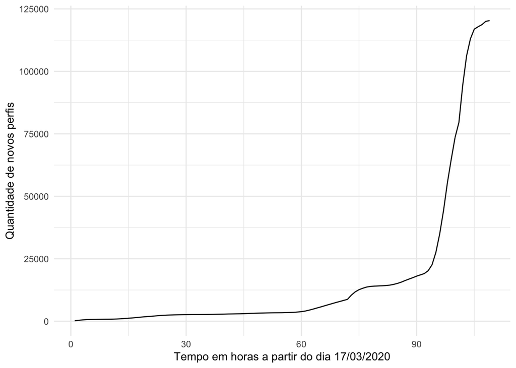

```r
tbl_acc <- tbl_ajuste %>%
  filter(is_retweet == FALSE) %>%
  distinct(screen_name, .keep_all = TRUE) %>%
  group_by(time) %>%
  summarise(n = n()) %>%
  mutate(n = cumsum(n)) %>%
  mutate(t = as.numeric((time - min(time))/3600)+ 1)


tbl_acc %>%
  ggplot(aes(x = t, y = n)) +
  geom_line() +
  labs(x = "Tempo em horas a partir do dia 17/03/2020",
       y = "Quantidade de novos perfis") +
  theme_minimal()
```

Os números totais para publicações, excluindo os retweets, são significativamente menores. Porém, observa-se o mesmo comportamento que ao se contemplar todas informações, porém com uma taxa inferior.

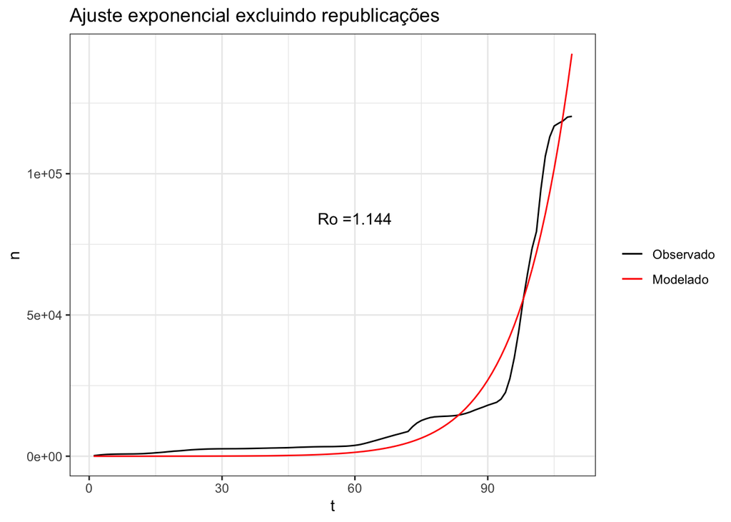

```r
aux <- nls2(n ~ exp_(t, R, d), data = tbl_acc, start = list(R = 100, d = 0.05),
            trace = F,
            control = nls.control(maxiter = 1000, minFactor=2^-12))

Ro <- summary(aux)[["coefficients"]][1,1]

d <- summary(aux)[["coefficients"]][1,2]



p2 <- tbl_acc %>%
  mutate(stat = predict(aux,tbl_acc)) %>%
  ggplot() +
  geom_line(aes(x = t, y = n, col = "black")) +
  geom_line(aes(x = t, y = stat, col = "red")) +
  ggplot2::annotate("text",  label = paste0("Ro =", "", round(Ro,3)),
           x = 60, y = 0.7*max(tbl_acc$n)) +
  scale_color_manual(values = c("black", "red"),
                     labels = c("Observado", "Modelado")) +
  labs(col = "", title = "Ajuste exponencial excluindo republicações") +
  theme_bw()

p2
```

## 2.3 Comparando as duas abordagens

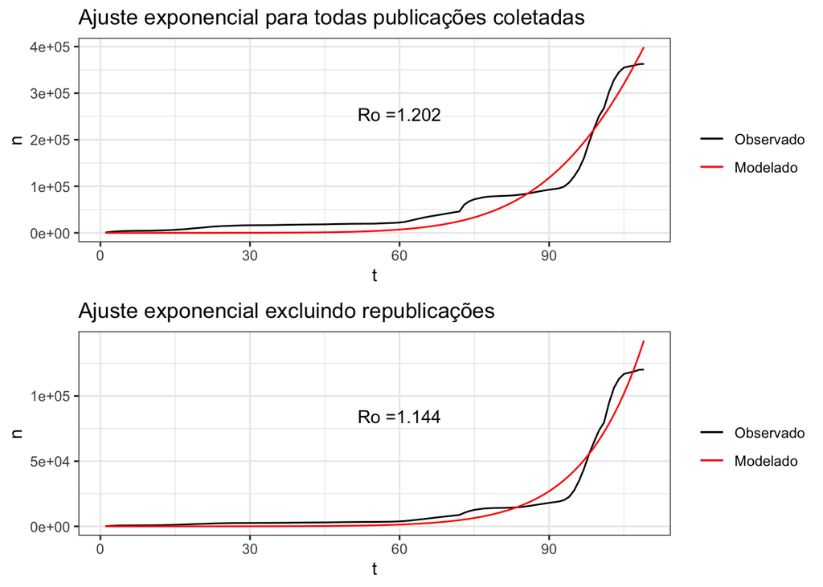

```r
gridExtra::grid.arrange(p1, p2)
```

Percebe-se que ambos apontam para uma região bem próxima de Ro, que representa a taxa de crescimento, se diferenciando pelo retardamento do crescimento desta informação. Interessante observar, também, que a proximidade entre a taxa de crescimento encontrada tanto para a totalidade das publicações como para aquelas que não são republicações validam uma metodologia pautada apenas na última.

Sendo $R_o$ maior que 1, observa-se que o aparecimento de novos usuários publicando sobre o tema em destaque ainda é crescente. Uma sugestão é esperar mais uma semana e ver qual o comportamento nesta semana.

Além disto, estes valores podem estar contaminados por perfis falsos, desinformações e fake news. Por isto, também, é necessário que planejemos uma estratégia para classificar em informação e desinformações e entender a taxa de crescimento de ambas.

# 3 Testando algumas redes:

## 3.1 Ajustes Iniciais (ver code):

```r
# Filtrando apenas não replicações

word_ajuste <- tbl_ajuste %>%
  filter(is_retweet == FALSE)

text <- word_ajuste$text %>%
  tolower() %>%
  as.tibble() %>%
  mutate(value = stri_trans_general(value, "Latin-ASCII"))
# Removendo palavras de não interesse

nowords <- c("sei", "to", "sobre", "ja", "ta", "vai", "nao", "📈", "🤦♀",
            "tendo", "poucos", "obg", "desses", "tudo", 'vdd', "
             mil", "so", "pra", "tudo", "n", "q", "vou", "ter", "pq", "tds",
             "+", "la", "fez", "vcs", "pro", "etc", "nada", "oq",
             "voce", "ver", "vc", 'ficar', "toda")

# Centro das redes:

  word <- c("@minsaude", "@who", "@UN", "@ABRASCO",
          "@lhmandetta", "@anvisa_oficial")


# Função de ajuste dos usuários ligados aos usuários acima:

  # toks_news <- tokens(text$value, remove_punct = TRUE)
  #
  # toks_news <- tokens_select(toks_news, pattern = stopwords('pt'),
  #                            selection = 'remove')
  #
  # toks_news <- tokens_select(toks_news, pattern = nowords,
  #                            selection = 'remove')

  load(file = "token.RData")

  f_chi2 <- function(x) {

  toks_keep <- tokens_keep(toks_news, pattern = word[x], window = 50)

  toks_nokeep <- tokens_remove(toks_news, pattern = word[x], window = 50)

  # dfm

  dfmat_keep <- dfm(toks_keep)

  dfmat_nokeep <- dfm(toks_nokeep)

  # t-test

  tstat_key_keep <- textstat_keyness(rbind(dfmat_keep, dfmat_nokeep),
                                     seq_len(ndoc(dfmat_keep)))

  tstat_key_keep_subset <- tstat_key_keep[tstat_key_keep$n_target > 1, ]

  aux <- tstat_key_keep_subset %>%
    filter(str_detect(feature, "@")) %>%
    head(15) %>%
    mutate(id = word[x])


}
```

## 3.2 Grafo:

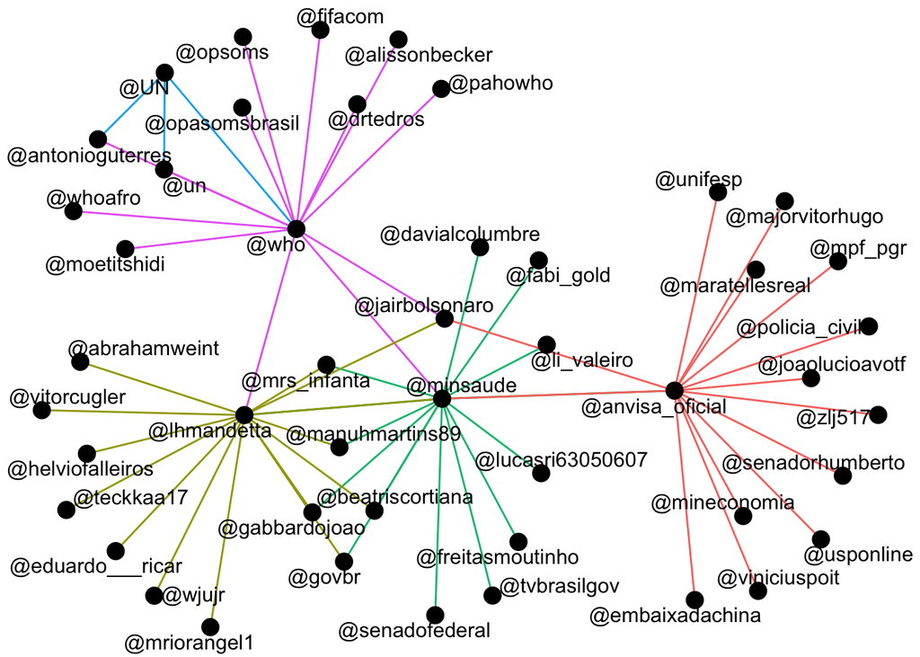

```r
data_graph <- 1:length(word) %>%
  map(f_chi2)


df <- data_graph %>% {
  tibble(
    feature = unlist(map(., "feature")),
    id = unlist(map(., "id")),
    chi2 = unlist(map(., "chi2")),
    n_ref = unlist(map(., "n_target"))
  )}


# mutate edges and nodes

grafico_pal <- df %>%
  mutate(type = id) %>%
  as_tbl_graph() %>%
  ggraph("kk") +
  geom_edge_link(aes(col = type), show.legend = FALSE) +
  geom_node_point(color = "black", fill = "white", size = 4) +
  geom_node_text(aes(label = name), repel = TRUE,
                 size= 4, color="black") +
  theme_void()

grafico_pal
```

Agora é preciso entender o padrão destes twitters. Vou gerar um txt com os perfís, é importante (se quisermos estudar estas interações) que tracemos uma estratégia para entender o que este cenário da rede significa, uma vez que há muitos anônimos entre os perfis.

Algumas outras observações:

1 - Fifa e who: https://nacoesunidas.org/fifa-e-oms-se-unem-para-combater-o-coronavirus/

2 - Antonio Guterres: https://valor.globo.com/mundo/noticia/2020/03/26/nao-estamos-ganhando-a-guerra-contra-o-virus-diz-secretario-da-onu.ghtml

3 - Dr Tedros: https://www.who.int/antimicrobial-resistance/interagency-coordination-group/dg_who_bio/en/

Mas ao chegar no Brasil, tem todo tipo de perfil.

# 4 Primeiro Ajuste:

## 4.1 Passando para escala diária:

### 4.1.1 Contando todas publicaçoes captadas pela API:

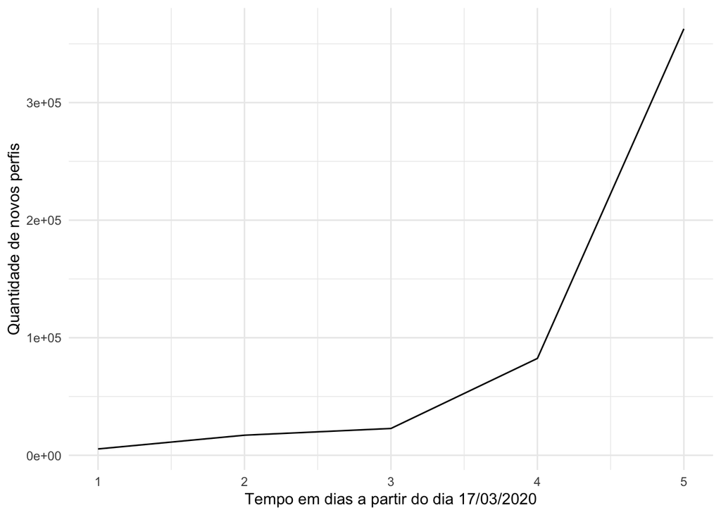

```r
tbl_ajuste <- tbl %>%
  mutate(time = lubridate::ymd_hms(created_at, tz = "America/Bahia")) %>%
  mutate(time = lubridate::round_date(created_at, unit = "day")) %>%
  select(-created_at)


tbl_acc <- tbl_ajuste %>%
  distinct(screen_name, .keep_all = TRUE) %>%
  group_by(time) %>%
  summarise(n = n()) %>%
  mutate(n = cumsum(n)) %>%
  mutate(t = as.numeric((time - min(time))/(3600*24))+ 1)


tbl_acc %>%
  ggplot(aes(x = t, y = n)) +
  geom_line() +
  labs(x = "Tempo em dias a partir do dia 17/03/2020",
       y = "Quantidade de novos perfis") +
  theme_minimal()
```

#### 4.1.1.1 Determinando Ro

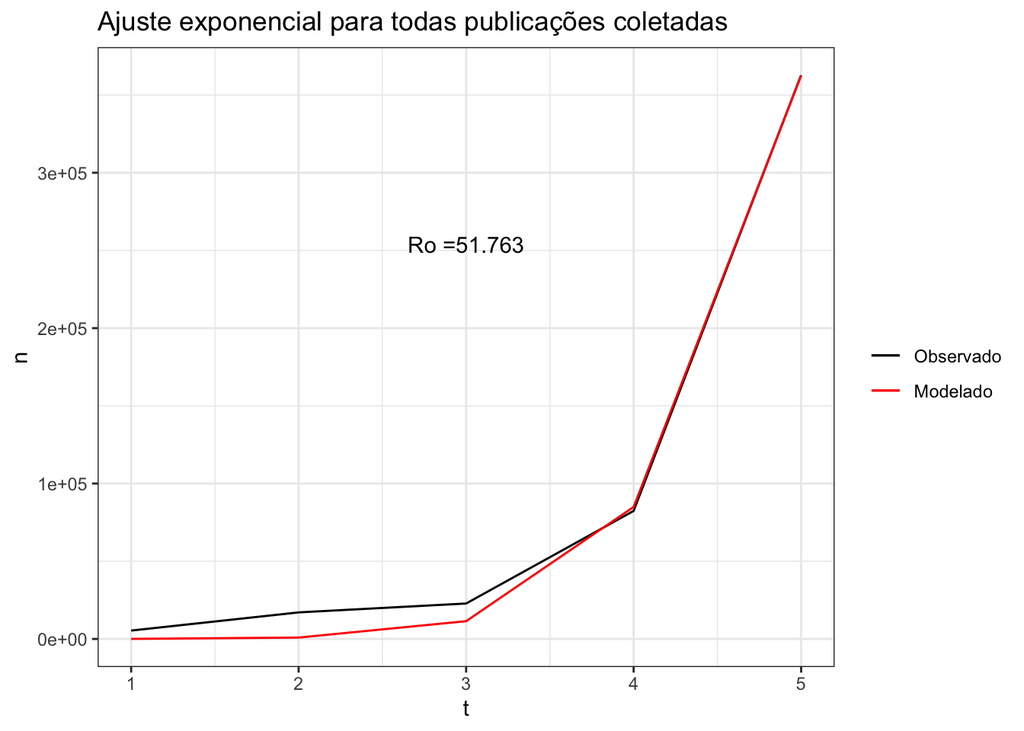

```r
exp_ <- function(t, R, d){

  (R/((1+d)^t))^t
}


aux <- nls2(n ~ exp_(t, R, d), data = tbl_acc, start = list(R = 1000, d = 0.05),
            trace = F,
            control = nls.control(maxiter = 5000, minFactor=2^-12))

Ro <- summary(aux)[["coefficients"]][1,1]

d <- summary(aux)[["coefficients"]][1,2]



p4 <- tbl_acc %>%
  mutate(stat = predict(aux,tbl_acc)) %>%
  ggplot() +
  geom_line(aes(x = t, y = n, col = "black")) +
  geom_line(aes(x = t, y = stat, col = "red")) +
  ggplot2::annotate("text",  label = paste0("Ro =", "", round(Ro,3)),
           x = 3, y = 0.7*max(tbl_acc$n)) +
  scale_color_manual(values = c("black", "red"),
                     labels = c("Observado", "Modelado")) +
  labs(col = "", title = "Ajuste exponencial para todas publicações coletadas") +
  theme_bw()

p4
```

### 4.1.2 Para publicações únicas:

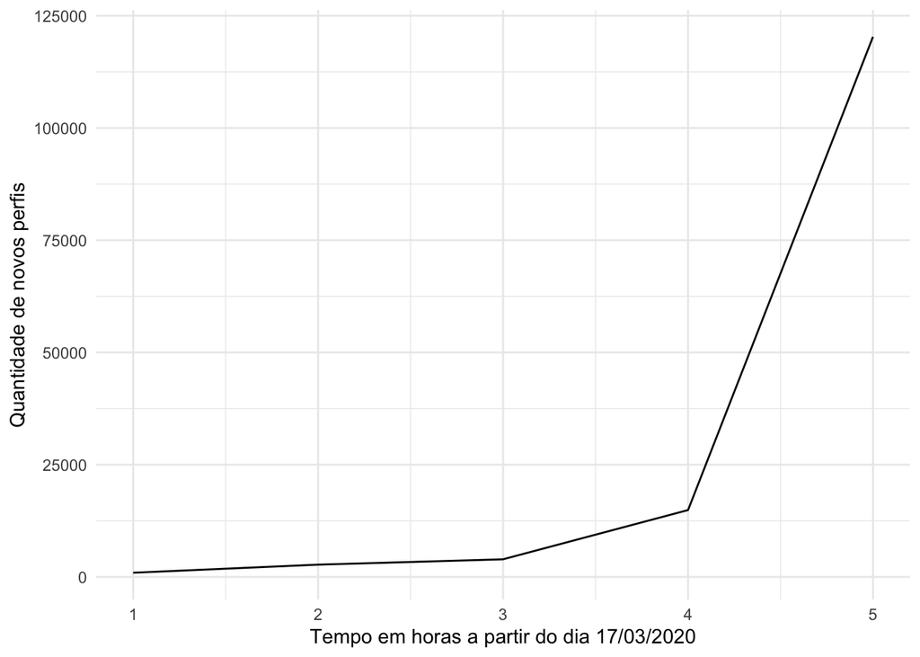

```r
tbl_ajuste <- tbl %>%
  mutate(time = lubridate::ymd_hms(created_at, tz = "America/Bahia")) %>%
  mutate(time = lubridate::round_date(created_at, unit = "day")) %>%
  select(-created_at)

tbl_acc <- tbl_ajuste %>%
  filter(is_retweet == FALSE) %>%
  distinct(screen_name, .keep_all = TRUE) %>%
  group_by(time) %>%
  summarise(n = n()) %>%
  mutate(n = cumsum(n)) %>%
  mutate(t = as.numeric((time - min(time))/(3600*24))+ 1)


tbl_acc %>%
  ggplot(aes(x = t, y = n)) +
  geom_line() +
  labs(x = "Tempo em horas a partir do dia 17/03/2020",
       y = "Quantidade de novos perfis") +
  theme_minimal()
```

#### 4.1.2.1 Determinado o Ro

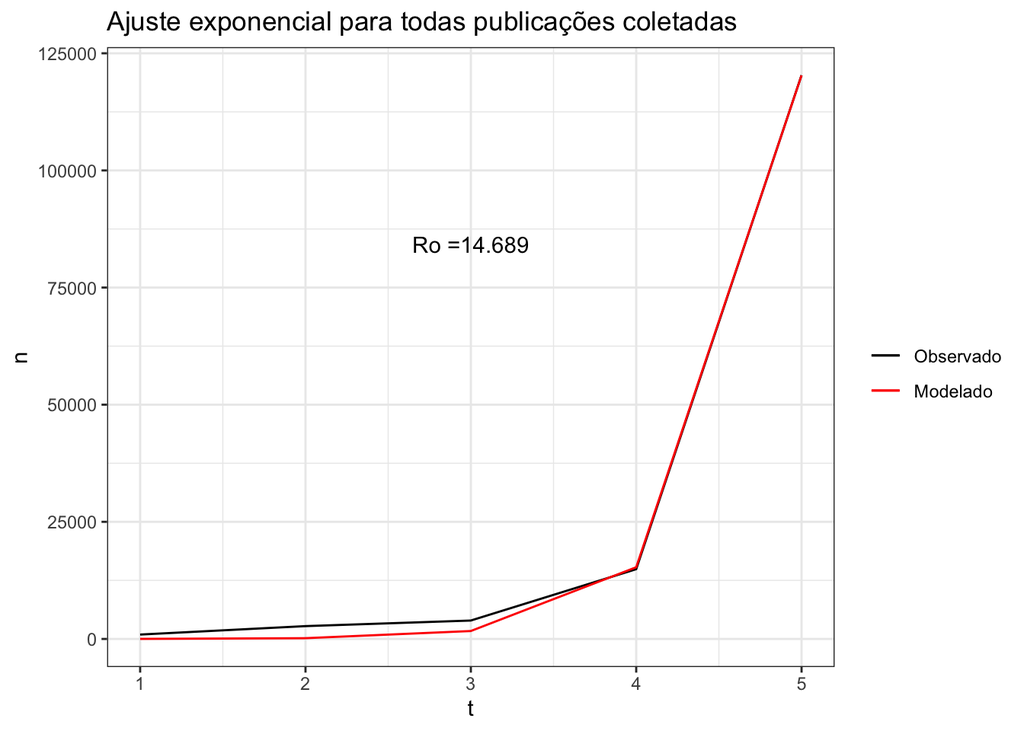

```r
exp_ <- function(t, R, d){

  (R/((1+d)^t))^t
}


aux <- nls2(n ~ exp_(t, R, d), data = tbl_acc, start = list(R = 1000, d = 0.05),
            trace = F,
            control = nls.control(maxiter = 5000, minFactor=2^-12))

Ro <- summary(aux)[["coefficients"]][1,1]

d <- summary(aux)[["coefficients"]][1,2]



p5 <- tbl_acc %>%
  mutate(stat = predict(aux,tbl_acc)) %>%
  ggplot() +
  geom_line(aes(x = t, y = n, col = "black")) +
  geom_line(aes(x = t, y = stat, col = "red")) +
  ggplot2::annotate("text",  label = paste0("Ro =", "", round(Ro,3)),
           x = 3, y = 0.7*max(tbl_acc$n)) +
  scale_color_manual(values = c("black", "red"),
                     labels = c("Observado", "Modelado")) +
  labs(col = "", title = "Ajuste exponencial para todas publicações coletadas") +
  theme_bw()

p5
```

Os valores de Ro se tornam bastante diferentes quando utilizamos esta escala, atigindo valores de alta magnitude como 50 e 14 para, respectivamente, todas publicações captadas pela API e apenas publicações unicas.